# prosperLoanData

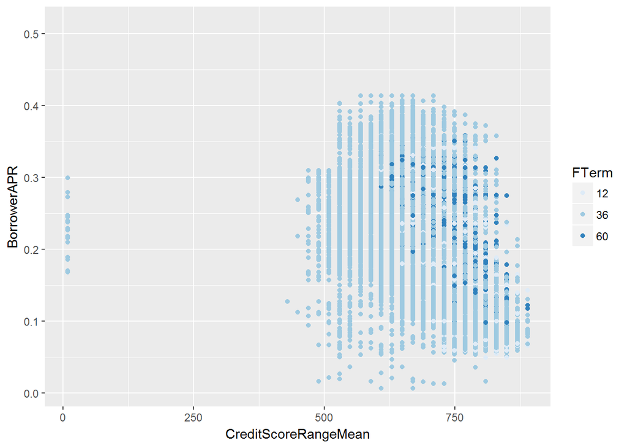

[output not shown]

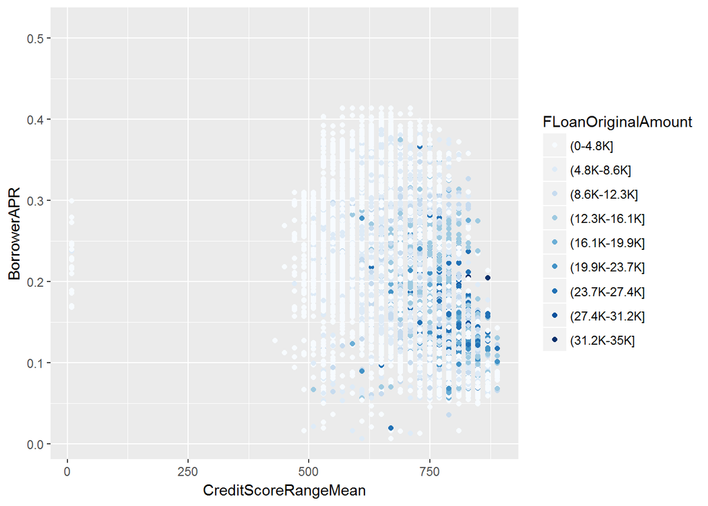

[output not shown]

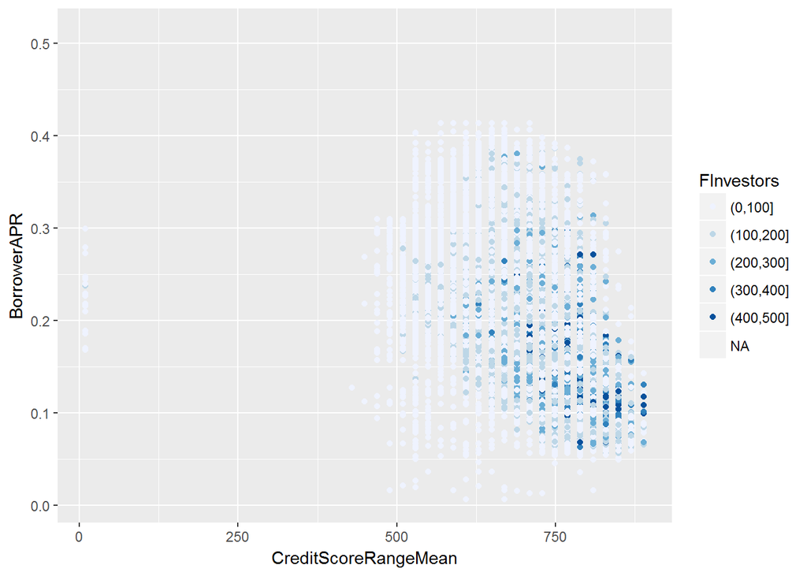

[output not shown]

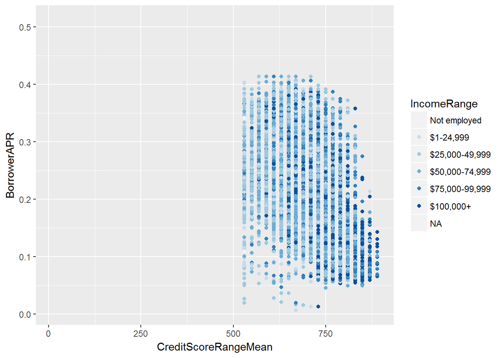

[output not shown]

## 5.2. Sessão de Gráficos Multivariados com as variáveis BorrowerAPR e LoanOriginalAmount:

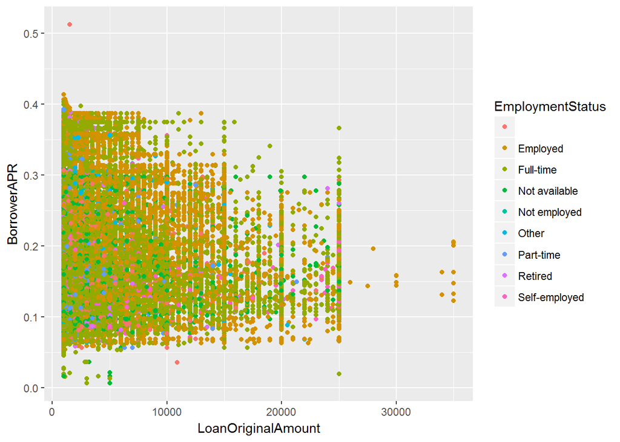

```
##
## [1] "- Observações:  Não observa-se no comportamento estre as variáveis qualquer indício de que exista alguma relação entre elas."
```

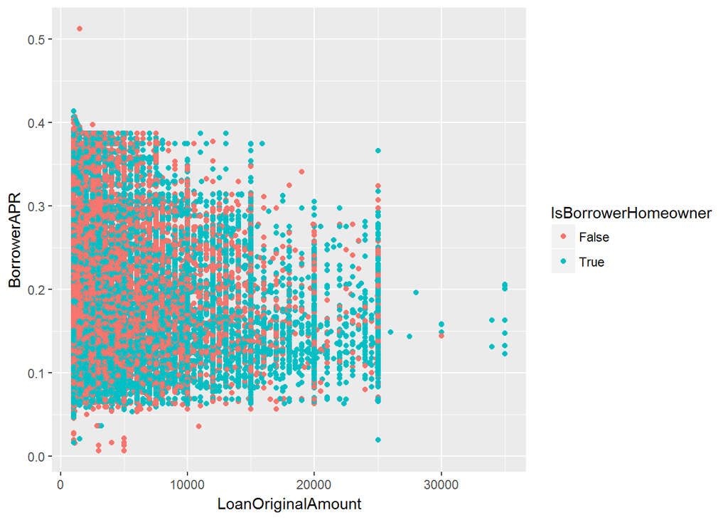

```
##
## [1] "- Observações:  Não observa-se no comportamento estre as variáveis qualquer indício de que exista alguma relação entre elas."
```

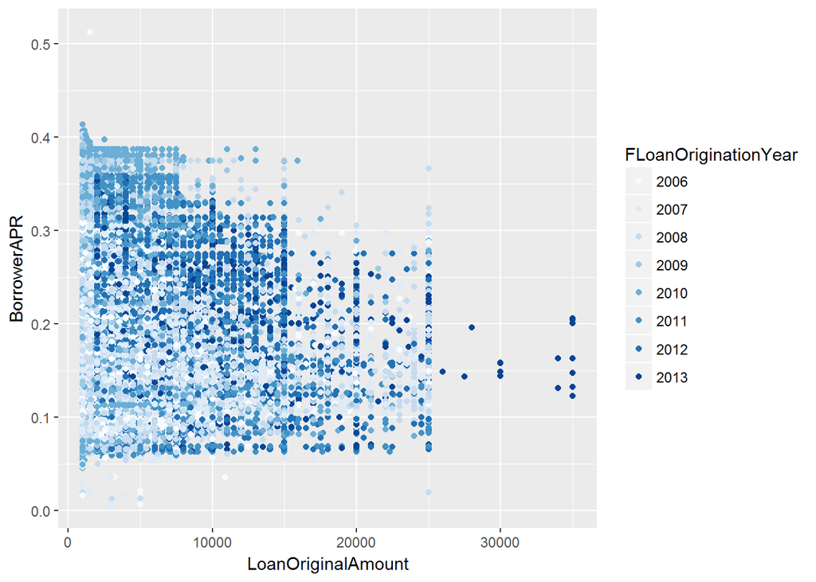

```
##
## [1] "- Observações:  Percebe-se uma tendência à um aumento no valor dos empréstimos concedidos e também na taxa de juros anuais aplicada."
```

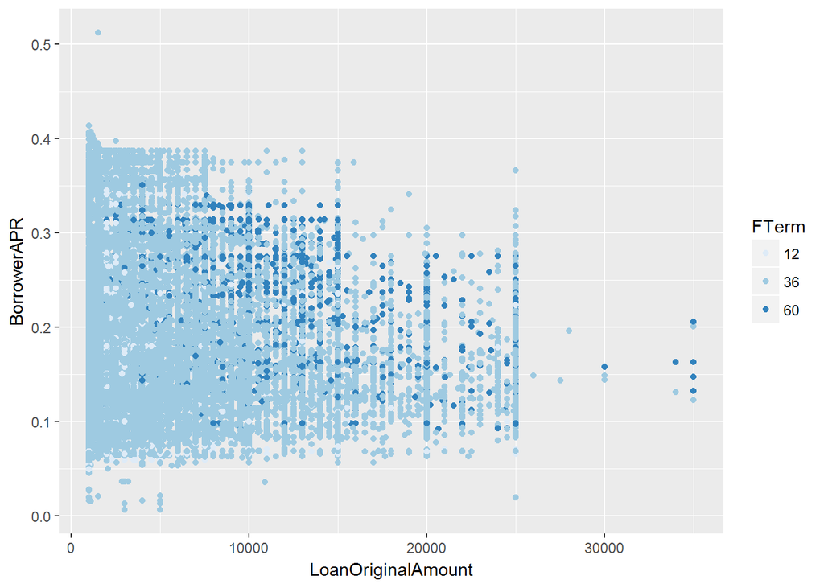

```
##
## [1] "- Observações:  Nesta distribuição por pontos, fica difícil perceber a ocorrência dos empréstimos com prazos diferentes de 36 meses, pois estes representam a grande maioria."
```

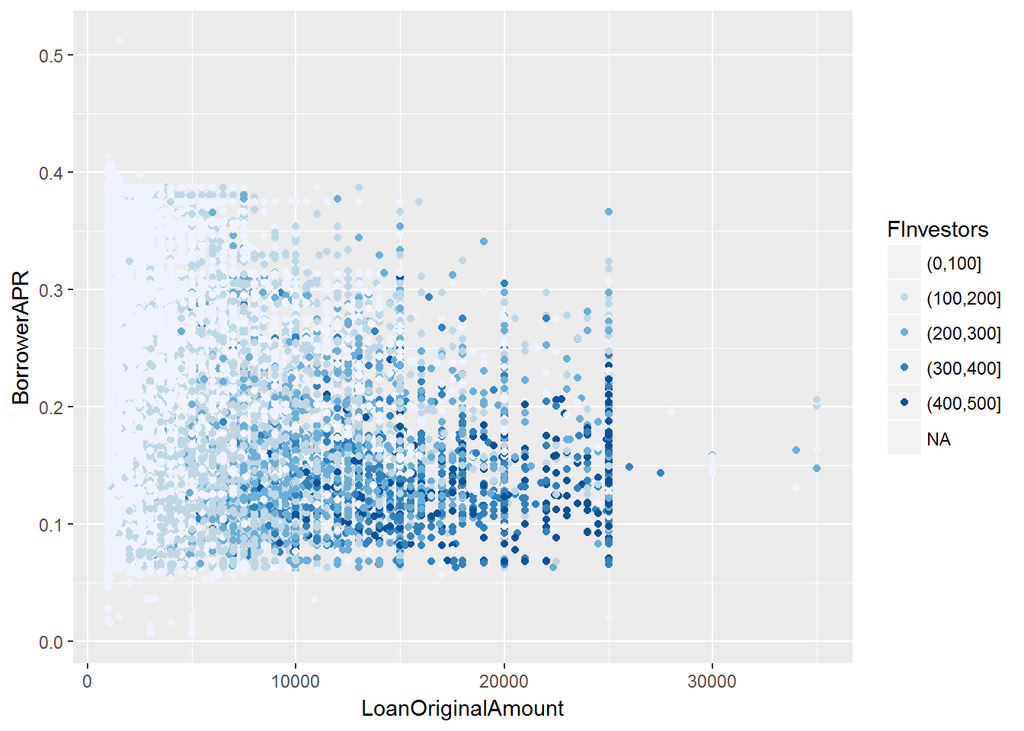

```
##
## [1] "- Observações:  Como foi observado nas correlações bivariadas, novamente percebe-se uma certa tendência em empréstimos de valores maiores apresentarem um maior número de investidores."
```

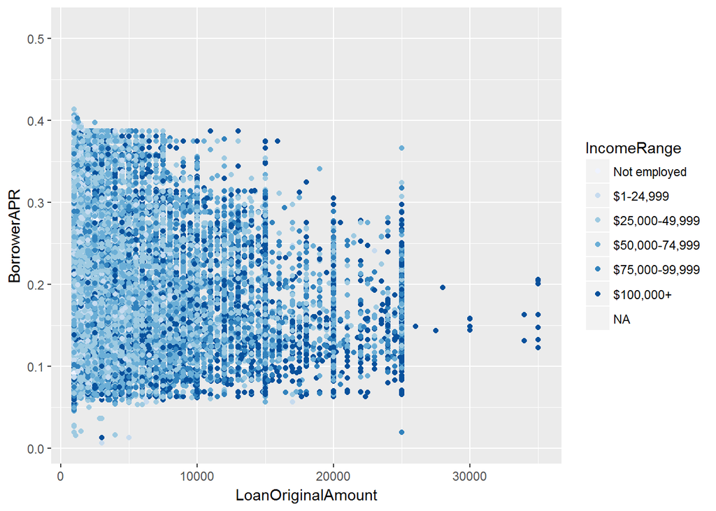

```
##
## [1] "- Observações:  Não observa-se no comportamento estre as variáveis qualquer indício de que exista alguma relação entre elas."
```

## 5.3. Sessão de Gráficos Multivariados com as variáveis BorrowerAPR e Investors:

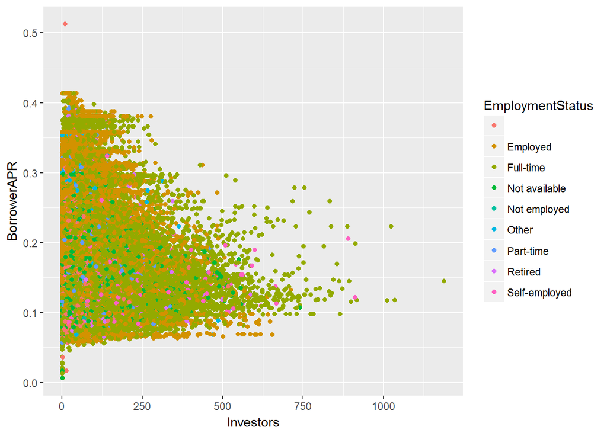

```
##
## [1] "- Observações:  Não observa-se no comportamento estre as variáveis qualquer indício de que exista alguma relação entre elas."
```

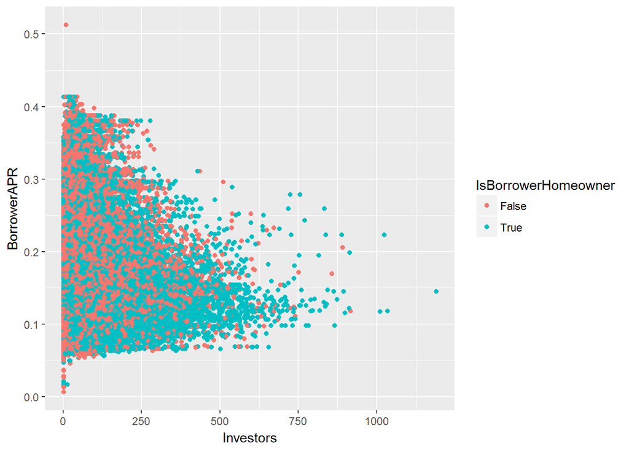

```
##
## [1] "- Observações:  Não observa-se no comportamento estre as variáveis qualquer indício de que exista alguma relação entre elas."
```

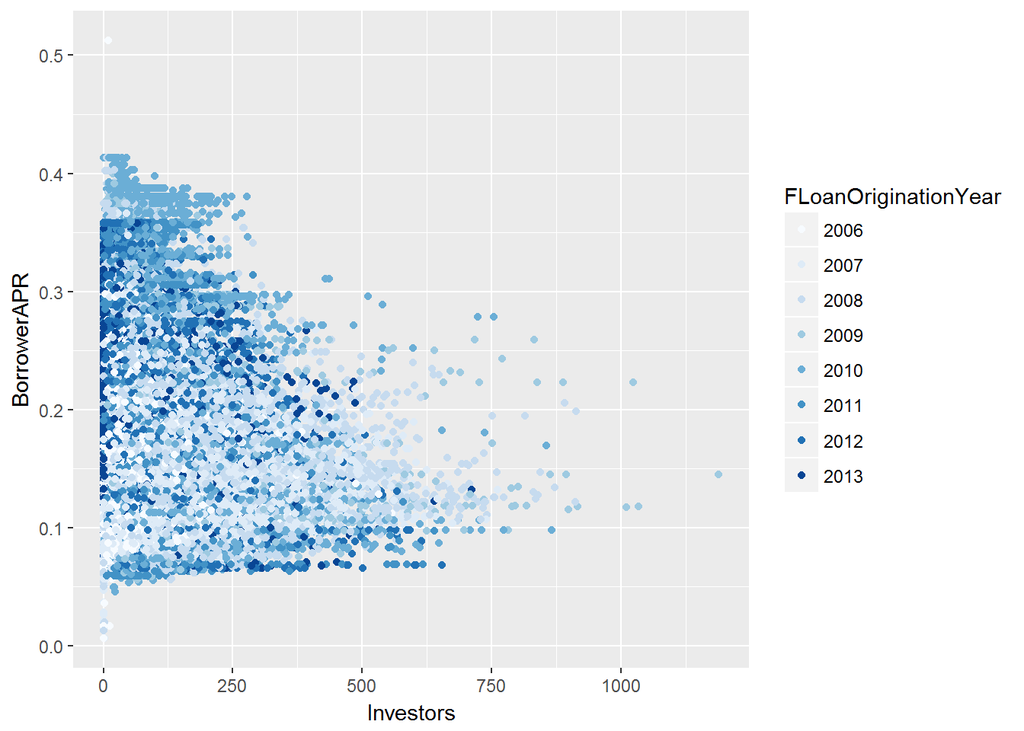

```
##
## [1] "- Observações:  Percebe-se na distribuição um aumento gradual da taxa de juros aprovada e uma diminuição do número de investidores por empréstimo ao longo dos anos."
```

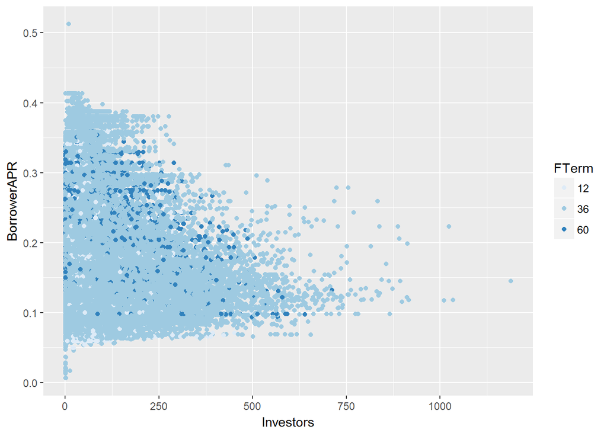

```
##
## [1] "- Observações:  Nesta distribuição por pontos, fica difícil perceber a ocorrência dos empréstimos com prazos diferentes de 36 meses, pois estes representam a grande maioria."
```

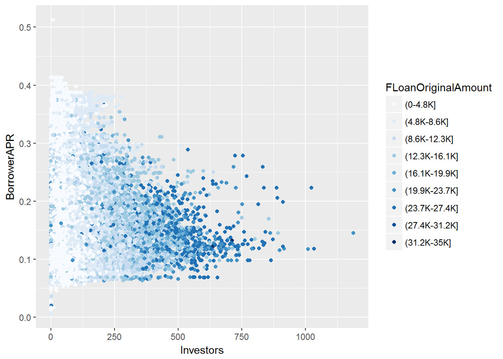

```
##
## [1] "- Observações:  Observa-se que o número de investidores aumenta conforme aumenta o valor do empréstimo, entretanto, a taxa de juros anuais aprovada tende à diminuir."
```

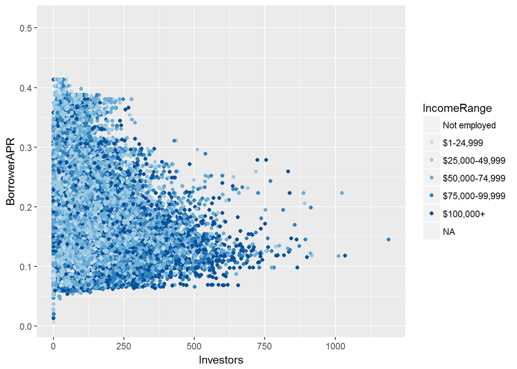

```
##
## [1] "- Observações:  Não observa-se no comportamento estre as variáveis qualquer indício de que exista alguma relação entre elas."
```

## 5.4. Conclusões das Análises MULTIVARIADAS

Observando as semelhanças e diferenças entre os conjuntos de gráficos, destaca-se:

- Constata-se que da mesma forma que Investors e LoanOriginalAmount são influenciadas da mesma maneira também em relação às demais variáveis do conjunto de dados. Neste caso, os gráficos de dispersão da variável LoanOriginalAmount com as demais variáveis possuem o mesmo formato dos gráficos de disersão da variável Investors com as demais variáveis.

Entretanto, observando a variável Investors contra a variável LoanOriginalAmount, não obtêm-se uma distribuição clara, apesar desta distribuição tender a explicar que quanto maior o valor de LoanOriginalAmount, maior o número de investidores.

# 6. SESSÃO DE GRÁFICOS FINAIS

### 6.1. Evolução do Volume de Transações

Inicialmente faz-se necessária a apresentação de um gráfico com o propósito de caracterizar o contexto referente ao comportamento do conjunto de dados em relação ao volume de concessão dos empréstimos ao longo do tempo e as respectivas taxas de juros anuais aplicadas aos mutuários nestes empréstimos.

Observou-se também que cerca de 76% do volume de empréstimo foi concedido com taxas de juros menores que 0,3%.

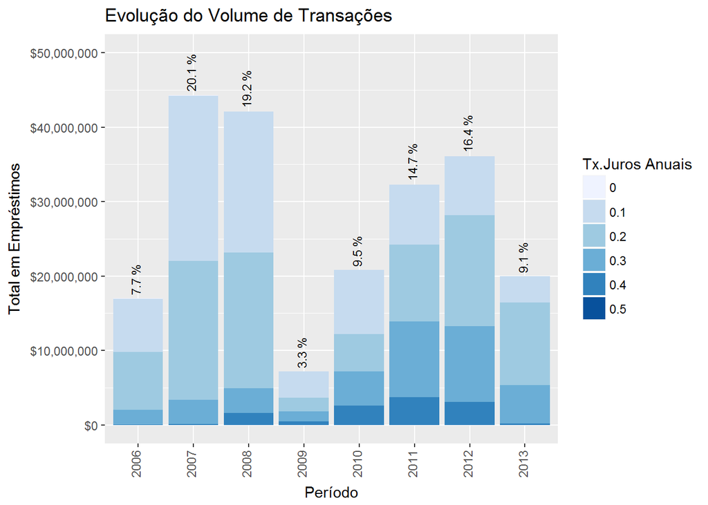

```
## [1] "> Estatísticas de Total em Empréstimos: "
```

```
##   FBorrowerAPR   x.mean x.min x.max    x.sum  x.perc
## 1            0 3647.917  1000 25000    87550  0.04 %
## 2          0.1 6995.378  1000 35000 79957175 36.39 %
## 3          0.2 6849.457  1000 35000 87803183 39.96 %
## 4          0.3 5320.492  1000 25000 40015419 18.21 %
## 5          0.4  3576.85  1000 25000 11867989   5.4 %
## 6          0.5     1500  1500  1500     1500     0 %
```

```
## [1] "- Total ->  $219,748,436"
```

### 6.2. DebtToIncomeRatio do mutuário x Juros aplicados

Um dos fatores importantes para caracterizar de que forma as taxas de juros são definidas para os empréstimos, é verificar quais as condições financeiras dos mutuários. Entre os indicadores disponíveis no conjunto de dados, foi selecionado o indicador “DebtToIncomeRatio”, pois este parece ser resultante da aplicação direta de uma fórmula considerando diversos outros indicadores financeiros (diferentemente dos indicadores “CreditScoreRangeLower” e “CreditScoreRangeUpper”, que tendem a ser menos precisos e talvez até depender da avaliação subjetiva de um avaliador de crédito).

Como por exemplo, para empréstimos negociados com taxas de juros anuais (BorrowerAPR) entre 0,2 e 0,299:

% Volume Faixa DebtToIncomeRatio 8.35 % 0.1 14.94 % 0.2 7.83 % 0.3 4.90 % 0.4 1.39 % 0.5 0.73 % 0.6

Assim, pode-se concluir no exemplo acima, que empréstimos dentro de uma mesma faixa de juros foram concedidos para mutuários independente do resultado do seu indicador DebtToIncomeRatio.

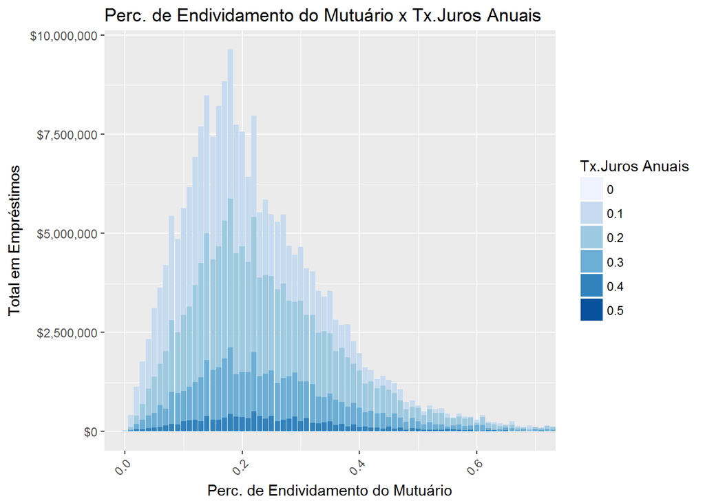

```
## [1] 0.2053796
```

```
## [1] "> Estatísticas de Total em Empréstimos: "
```

```
##    FBorrowerAPR FDebtToIncomeRatio    x.sum  x.perc
## 7             0                0.1    12500  0.01 %
## 12            0                0.2    16850  0.01 %
## 17            0                0.3     5100     0 %
## 22            0                0.4    25000  0.01 %
## 27            0                0.5     1000     0 %
## 8           0.1                0.1 25072673 11.41 %
## 13          0.1                0.2 29846478 13.58 %
## 18          0.1                0.3 11594181  5.28 %
## 23          0.1                0.4  5704454   2.6 %
## 28          0.1                0.5  1339262  0.61 %
## 32          0.1                0.6   600062  0.27 %
## 9           0.2                0.1 18338744  8.35 %
## 14          0.2                0.2 32838418 14.94 %
## 19          0.2                0.3 17197891  7.83 %
## 24          0.2                0.4 10771711   4.9 %
## 29          0.2                0.5  3059927  1.39 %
## 33          0.2                0.6  1611199  0.73 %
## 10          0.3                0.1  7676790  3.49 %
## 15          0.3                0.2 13892532  6.32 %
## 20          0.3                0.3  8435564  3.84 %
## 25          0.3                0.4  5194174  2.36 %
## 30          0.3                0.5  1836720  0.84 %
## 34          0.3                0.6   938851  0.43 %
## 11          0.4                0.1  2101173  0.96 %
## 16          0.4                0.2  4053899  1.84 %
## 21          0.4                0.3  2486912  1.13 %
## 26          0.4                0.4  1537956   0.7 %
## 31          0.4                0.5   554131  0.25 %
## 35          0.4                0.6   410772  0.19 %
```

```
## [1] "- Total ->  $219,748,436"
```

```
## [1] "- Obs. Considerados apenas empréstimos com FDebtToIncomeRatio até 0.6"
```

### 6.3. Retorno por Volume de Transação

Além da taxa de juros anuais aprovada, BorrowerAPR, temos também 2 outras informações importantes: que é o juros efetivamente aplicado nos empréstimos aos mutuários, BorrowerRate; e os juros de retorno aos investidores, LenderYield. A diferença entre essas taxas é o que caracterizamos como ganho da financeira, ProsperGain.

Assim, é importante verificarmos se a distribuição dos ganhos da financeira dependem ou não dos valores dos empréstimos e/ou da taxa de juros anuais aprovada. Ou seja, o volume de cada transação e à taxa de juros aprovada refletem no ganho de intermediação do serviço?

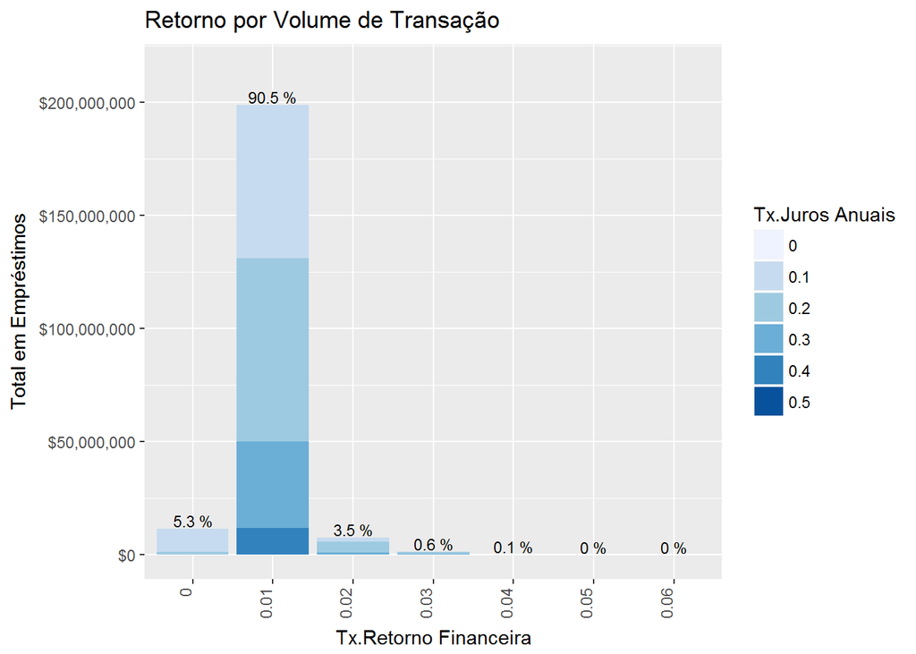

```
## [1] "> Estatísticas de Retorno Financeira: "
```

```
##    FLoanOriginalAmount FBorrowerAPR     x.sum  x.perc
## 1             (0-4.8K]            0     285.5  0.01 %
## 5             (0-4.8K]          0.1 105787.39  4.99 %
## 14            (0-4.8K]          0.2 154912.26  7.31 %
## 23            (0-4.8K]          0.3 127174.93     6 %
## 30            (0-4.8K]          0.4  78118.18  3.69 %
## 35            (0-4.8K]          0.5       7.5     0 %
## 2          (4.8K-8.6K]            0       125  0.01 %
## 6          (4.8K-8.6K]          0.1 180731.08  8.53 %
## 15         (4.8K-8.6K]          0.2 229725.53 10.84 %
## 24         (4.8K-8.6K]          0.3 127782.14  6.03 %
## 31         (4.8K-8.6K]          0.4  37613.19  1.77 %
## 3         (8.6K-12.3K]            0      54.5     0 %
## 7         (8.6K-12.3K]          0.1 143291.51  6.76 %
## 16        (8.6K-12.3K]          0.2 163866.29  7.73 %
```

[output cut: 21 more lines]

```
## [1] "- Total ->  $2,119,610"
```

# 7. REFLEXÃO

Abaixo relacionaremos alguns pontos de reflexão e aprendizado obtidos durante a análise do conjunto de dados “prosperLoanData”.

1. Contexto:
- O grau de dificuldade em realizar uma análise de dados pode ser maior ou menor dependendo do conhecimento e experiência do analista de dados na área relativa aos dados representados como também ao acesso deste à informações contextuais do conjunto de dados. Neste case, pesquisamos e encontramos o site www.prosper.com, que, ao que tudo indica, parece ser o site da instituição financeira provedora do conjunto de dados. Entretanto, apesar do nome do conjunto de dados sugerir ser esta a instituição, como também as similaridades entre as informações obtidas no site e o conjunto de dados, não podemos correr o risco de inferir que as regras dispostas no site referem-se ao conjunto de dados fornecido para análise. Creio que seria interessante se, junto com o conjunto de dados, pudessem ser fornecidas mais informações contextuais, como por exemplo, o site que apresenta informações do negócio relativo à empresa provedora dos dados.
2. Exploração dos Dados:
- Quando o conjunto de dados possui muitas variáveis é praticamente inevitável desenvolver funções que busquem automatizar os procedimentos de análises à serem aplicados às mesmas. Entretanto, é preciso tomar cuidado com a automatização de código, pois pode nos levar à conclusões equivocadas em relação às variáveis cujo comportamento saia do padrão mas sem ocasionar erro durante a execução do procedimento.
3. Conclusões:
- As conclusões referente cada etapa devem ser feitas somente quando exaurem-se as perguntas e descobertas relativas ao modelo de dados, pois trata-se de um processo de conhecimento do conjunto de dados, onde a revelação de determinado comportamento de uma variável pode levar à necessidade de revisão de todas as etapas de análise anteriores.
4. Conjunto de Dados: Em relação ao conjunto de dados, podemos concluir que:
- A taxa de juros a ser aplicada ao mutuário é o indicador que irá determinar também a taxa de retorno que terá os investidores que escolheram esse empréstimo.
- Os investidores escolhem os empréstimos e investem neles a quantia desejada até que a soma total dos valores investidos cubra o valor total do empréstimo solicitado pelo mutuário.
- Ainda que o indicadores de endividamento e de crédito, como por exemplo os indicadores “DebtToIncomeRatio”" e “CreditScoreRange” sejam utilizados para determinar a taxa de juros do empréstimo (e consequentemente a tax de retorno dos investidores), parecem existir variáveis reguladoras, baseados na oferta e na procura, que são efetivas na determinação da taxa no momento da contratação. Tais variáveis parecem visar garantir um equilíbrio entre a concessão de empréstimos à juros baixos e de investimentos à juros atrativos aos investidores.
5. Sugestões para trabalhos futuros:
- Um dos pontos interessante seria estudar uma forma de determinar a taxa de juros em função do risco da transação. Ou seja, dependendo do valor do empréstimo e do perfil do mutuário, a taxa de juros só seria determinada quando no fechamento total do valor pelos investidores. Nessas condições, quanto menor o número de investidores, maior o valor do empréstimo e mais arriscado o perfil do mutuário, maior é o risco para cada investidor (proporcional ao valor investido). Nesse cenário, seria interessante que o retorno aos investidores, e também à financeira, fosse proporcional ao risco envolvido.